# DS3 projects

## Gathered data ordinary least square regression

```r
fit.report <- lm(trends~ymd+bush+trump+obama, data=report |> filter(trends > 0))
fit.crime <- lm(trends~ymd+bush+trump+obama, data=crime |> filter(trends > 0))
fit.welfare <- lm(trends~ymd+bush+trump+obama, data=welfare |> filter(trends > 0))
summary(fit.report)
```

```
##
## Call:
## lm(formula = trends ~ ymd + bush + trump + obama, data = filter(report,
##     trends > 0))
##
## Residuals:
##     Min      1Q  Median      3Q     Max
## -20.306  -5.418  -1.076   4.252  38.740
##
## Coefficients: (1 not defined because of singularities)
##               Estimate Std. Error t value Pr(>|t|)
## (Intercept) 90.7739107 15.3446130   5.916 1.59e-08 ***
## ymd         -0.0027952  0.0009751  -2.867  0.00463 **
## bush         1.7209308  2.7105835   0.635  0.52629
## trump       18.6115465  2.6314099   7.073 3.11e-11 ***
## obama               NA         NA      NA       NA
## ---
## Signif. codes:  0 '***' 0.001 '**' 0.01 '*' 0.05 '.' 0.1 ' ' 1
##
## Residual standard error: 8.991 on 183 degrees of freedom
## Multiple R-squared:  0.2855, Adjusted R-squared:  0.2738
## F-statistic: 24.37 on 3 and 183 DF,  p-value: 2.569e-13
```

```r
summary(fit.crime)
```

```
##
## Call:
## lm(formula = trends ~ ymd + bush + trump + obama, data = filter(crime,
##     trends > 0))
##
## Residuals:
##     Min      1Q  Median      3Q     Max
## -22.848  -6.442  -3.853   3.012  63.302
##
## Coefficients: (1 not defined because of singularities)
##              Estimate Std. Error t value Pr(>|t|)
## (Intercept) 2.887e+00  2.684e+01   0.108   0.9145
## ymd         8.249e-04  1.700e-03   0.485   0.6282
## bush        9.877e+00  4.661e+00   2.119   0.0357 *
## trump       1.961e+01  4.308e+00   4.552  1.1e-05 ***
## obama              NA         NA      NA       NA
## ---
## Signif. codes:  0 '***' 0.001 '**' 0.01 '*' 0.05 '.' 0.1 ' ' 1
##
## Residual standard error: 13.97 on 148 degrees of freedom
## Multiple R-squared:   0.29,  Adjusted R-squared:  0.2757
## F-statistic: 20.15 on 3 and 148 DF,  p-value: 5.23e-11
```

```r
summary(fit.welfare)
```

```
##
## Call:
## lm(formula = trends ~ ymd + bush + trump + obama, data = filter(welfare,
##     trends > 0))
##
## Residuals:
##     Min      1Q  Median      3Q     Max
## -19.880  -7.361  -1.873   4.095  54.921
##
## Coefficients: (1 not defined because of singularities)
##              Estimate Std. Error t value Pr(>|t|)
## (Intercept) 47.556981  22.482828   2.115  0.03595 *
## ymd         -0.001323   0.001429  -0.926  0.35581
## bush        12.125788   3.925027   3.089  0.00236 **
## trump       20.303916   3.781089   5.370 2.71e-07 ***
## obama              NA         NA      NA       NA
## ---
## Signif. codes:  0 '***' 0.001 '**' 0.01 '*' 0.05 '.' 0.1 ' ' 1
##
## Residual standard error: 12.59 on 161 degrees of freedom
## Multiple R-squared:  0.3006, Adjusted R-squared:  0.2875
## F-statistic: 23.06 on 3 and 161 DF,  p-value: 1.799e-12
```

**Table 2.** *Gathered data immigration searches by presidential administration*  
The values from the dependent variables in the self gathered data has the trends seen in the original data. However, the difference in some of the data points mentioned in *Figure 2* create a variation in the trends from the gathered data.

## Topic Model

A structural topic model was used to measure changes in media coverage of immigrant-related issues before and after the 2016 election. The measure of the coverage was done on news networks CNN, FOX, and MSNBC. The topic model gather data relating to 30 different topics, news networks used, duration of the coverage, transcript, etc.  
*–For more clarification on this data please refer to page 9 of the research paper*

### Topic model plot function

The function replicates the topic model plots used in the original paper

```r
topic_plot <- function(df, lable) {
df |> ungroup() |>
  group_by(channel, time) |>
  ggplot(aes(x = yearmonth, y = summation, color = channel, group = interaction(channel, time))) +
  geom_vline(xintercept = as.numeric(date1), linetype = "dashed", color = "black") +
  geom_vline(xintercept = as.numeric(date2), linetype = "dashed", color = "black") +
  geom_point() + geom_smooth( se=FALSE) + scale_color_manual(values = my_colors) +
  theme(axis.title.x = element_blank(), legend.position = "bottom", legend.title = element_blank()) +
  ylab(lable)
}
```

### Preparing topic model data

Loading, mutating, correctly formatting the date and summarizing the topic model data for plotting

```r
# Loads the topic model
load("TopicModel.RData")
document_topics <- make.dt(immigrFit, meta = out$meta)
topic_terms <- t(exp(immigrFit$beta$logbeta[[1]]))
rownames(topic_terms) <- out$vocab
colnames(topic_terms) <- sprintf("Topic%d", 1:ncol(topic_terms))
```

```r
# converts the date to appropriate format
document_topics <- document_topics |>
   mutate(date = as.Date(date, format = "%Y-%m-%d"),yearmonth = ym(format(date, "%Y-%m")))

# grouping and summarizing based on date
time_line <- document_topics |>
  select(time, yearmonth) |>
  group_by(time) |>
  summarize(yearmonth = min(yearmonth))

# variables holding the date for partitioning
date1 <- as.Date("2015-06-01")
date2 <- as.Date("2017-01-01")

# variable to ensure proper coloring of plot
my_colors <- c("magenta", "red3", "blue")
```

### Preparing data for topic model plot

Separating the topic model data based on topic(i.e Topics 1 and 3 were used for crime topics while Topic 13 was used for welfare topics)

```r
# grouping and filtering by news channel
plot_2_table <- document_topics |>
  select(channel, duration, yearmonth, time) |> group_by(yearmonth, channel, time) |>
  summarize(summation=sum(duration)) |> arrange(summation)

# grouping and filtering by news channel and crime rhetoric
plot_3a_table <- document_topics |>
  select(Topic1, Topic3, channel, duration, yearmonth, time) |> group_by(yearmonth, channel, time) |>
  summarize(summation=sum(duration*Topic1 + duration*Topic3)) |> arrange(summation)

# grouping and filtering by news channel and welfare rhetoric
plot_3b_table <- document_topics |>
  select(Topic13, channel, duration, yearmonth, time) |> group_by(yearmonth, channel, time) |>
  summarize(summation=sum(duration*Topic13)) |> arrange(summation)
```

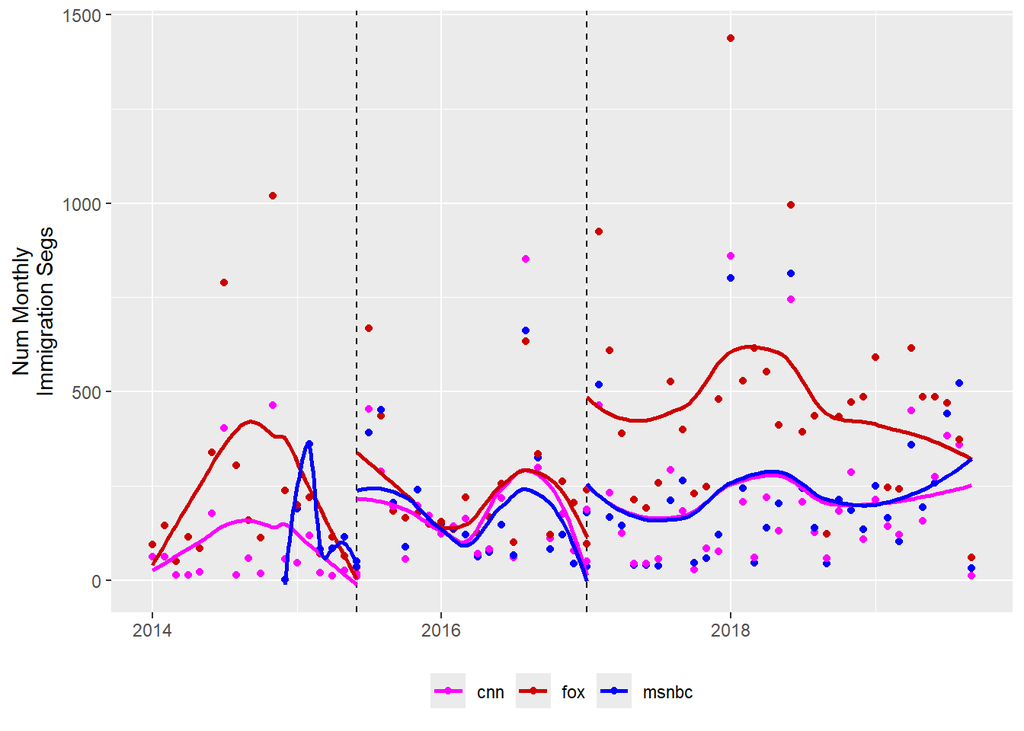

```r
topic_plot(plot_2_table, "Num Monthly\nImmigration Segs")
```

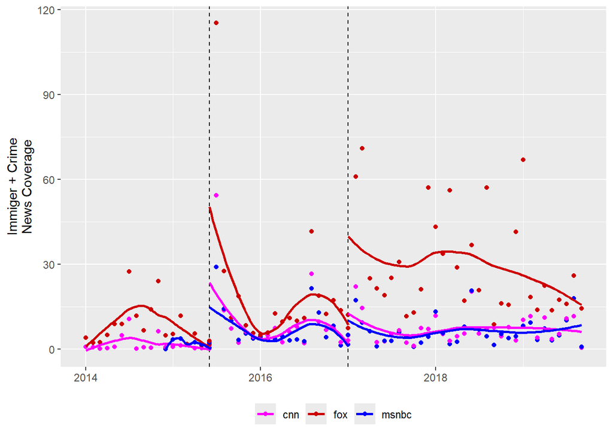

```r
topic_plot(plot_3a_table, "Immiger + Crime\nNews Coverage")
```

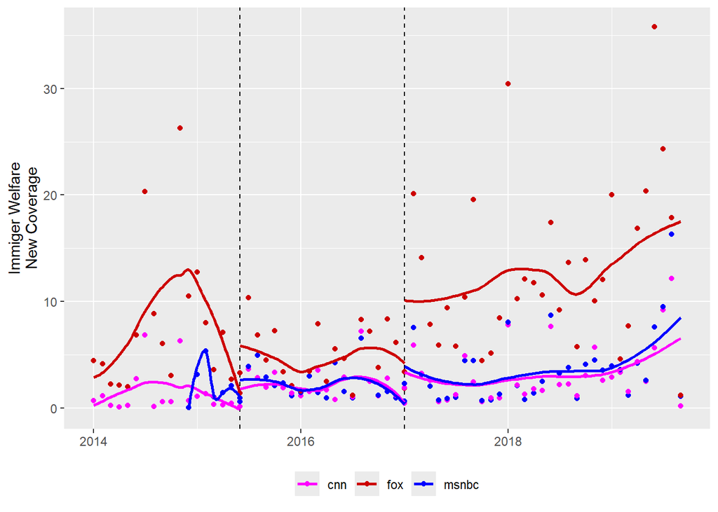

```r
topic_plot(plot_3b_table , "Immiger Welfare\nNew Coverage")
```

*The dotted black lines separate key moments in Trumps administration, the first when the Trump campaign began and the second is the start of his presidency*

## Recreating media coverage and reporting search trends

Selecting, filtering, and summarizing the daily search data and then joining it with the topic model for further examination

```r
# importing daily trends data
daily <- read.csv("google-trends data/replicate data/gt_report_daily.csv") |> select(date, search, search_adj) |>  mutate(date=as.Date(date))
```

```r
# filtering and selecting only the most influential topics with regard to reporting, crime, and welfare
filtered_topics <- document_topics |>
  select(date, channel, duration, Topic1, Topic3, Topic13) |> group_by(date) |>
  summarize(duration=sum(duration), Topic1and3=sum(Topic1 + Topic3), Topic13=sum(Topic13))
```

```r
# obtaining the searches happening during the particular topic new coverage
filtered_topics <- filtered_topics |> inner_join(daily, join_by(date))
```

## Media coverage and reporting search trends

Creating a liner ordinary least square regression model for the daily searches and topics during the Trump administration

```r
# dates for partitioning
bush_end <- as.Date("2009-01-20")
trump_start <- as.Date("2017-01-20")

# include presidencies on row date
filtered_topics$president <-
  ifelse(filtered_topics$date >= bush_end & filtered_topics$date < trump_start, "obama",
       ifelse(filtered_topics$date < bush_end, "bush", "trump"))

# create true/false columns, one for each presidency, for the linear model
filtered_topics$trump <-
  ifelse(filtered_topics$president == "trump", TRUE, FALSE)

filtered_topics <- filtered_topics %>%
mutate(month = month(date, label = TRUE, abbr = FALSE))

filtered_topics <- filtered_topics %>%
mutate(day_of_week = wday(date, label = TRUE, abbr = FALSE))

# create the linear model and fit the data
fit.coverage <- lm(search_adj~duration+Topic1and3+Topic13+trump+date+month+day_of_week, data=filtered_topics)
summary(fit.coverage)
```

```
##
## Call:
## lm(formula = search_adj ~ duration + Topic1and3 + Topic13 + trump +
##     date + month + day_of_week, data = filtered_topics)
##
## Residuals:
##     Min      1Q  Median      3Q     Max
## -45.814 -11.965  -1.945   9.044 135.937
##
## Coefficients:
##                 Estimate Std. Error t value Pr(>|t|)
## (Intercept)   109.584471  23.731562   4.618 4.13e-06 ***
## duration        0.045549   0.019122   2.382 0.017309 *
## Topic1and3      0.733940   0.263840   2.782 0.005457 **
## Topic13         2.266620   0.673892   3.363 0.000784 ***
## trumpTRUE      19.537663   1.694791  11.528  < 2e-16 ***
## date           -0.004388   0.001427  -3.074 0.002141 **
## month.L       -10.045117   1.504811  -6.675 3.18e-11 ***
## month.Q         8.494530   1.451830   5.851 5.70e-09 ***
## month.C        -2.946282   1.466928  -2.008 0.044727 *
## month^4         2.864202   1.467697   1.951 0.051137 .
## month^5         1.956103   1.465239   1.335 0.182026
## month^6        -4.992703   1.473888  -3.387 0.000719 ***
## month^7         1.426701   1.457228   0.979 0.327673
## month^8        -0.334775   1.453648  -0.230 0.817882
## month^9        -1.070189   1.447434  -0.739 0.459769
## month^10       -0.994749   1.420718  -0.700 0.483900
## month^11        1.614120   1.409658   1.145 0.252328
## day_of_week.L   1.293711   1.103600   1.172 0.241230
## day_of_week.Q  -6.798711   1.108536  -6.133 1.04e-09 ***
## day_of_week.C  -0.622007   1.102206  -0.564 0.572593
## day_of_week^4  -1.020480   1.101801  -0.926 0.354457
## day_of_week^5   2.492456   1.101831   2.262 0.023798 *
## day_of_week^6  -1.721800   1.099503  -1.566 0.117511
## ---
## Signif. codes:  0 '***' 0.001 '**' 0.01 '*' 0.05 '.' 0.1 ' ' 1
##
## Residual standard error: 18.75 on 2007 degrees of freedom
## Multiple R-squared:  0.2643, Adjusted R-squared:  0.2563
## F-statistic: 32.78 on 22 and 2007 DF,  p-value: < 2.2e-16
```

**Table 3.** *Media coverage and reporting searches*  
The reproduced regression is not the same one seen in the paper. Although, it does show similar correlations and trend, which show that the coverage of unauthorized immigrant crimes and welfare usage is positively correlated with higher searches for immigrant reporting.

## Extension:

##### 1) How searches regarding immigrant success stories and immigrant aid changed over the same time

##### 2) How fear vs positive searches vary thorugh the different states

### Positive Google trend terms

**Positive**(i.e. positive terms): immigrant success + immigrant contribution + benefits of immigration + help immigrant

## Proportion of fear vs positive search terms

```r
vs <- read.csv("google-trends data/FvsS/fearvssuccess.csv")
map <- read.csv("google-trends data/FvsS/fearvssuccess_geo.csv")

# changing column names to be easier to work with
colnames(vs) <- c("ym" ,"fear", "success")
```

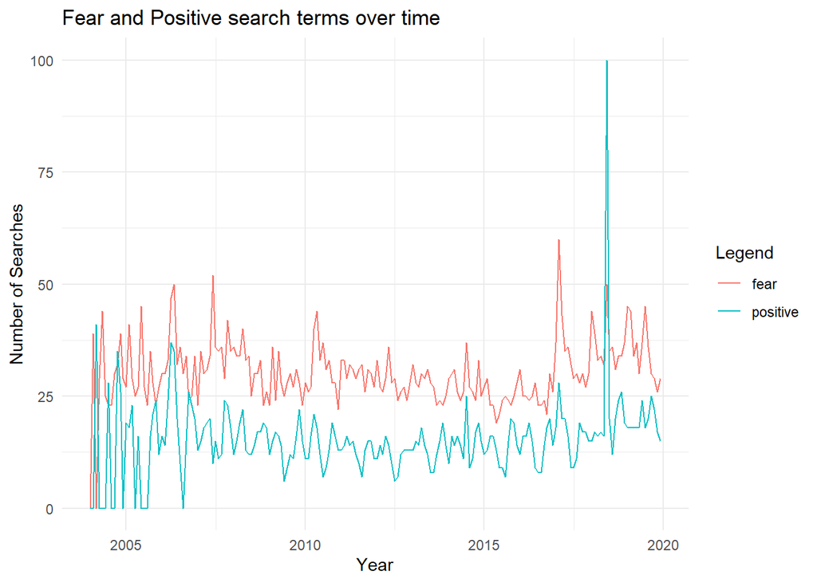

```r
vs <- vs %>%
  mutate(ymd = ymd(paste0(ym, "-01")))

ggplot(data = vs, aes(x = ymd)) +
  geom_line(aes(y = fear, color = "fear")) +
  geom_line(aes(y = success, color = "positive")) +
  labs(y = "Values", color = "Legend") +
  theme_minimal() +
  xlab("Year") +
  ylab("Number of Searches") +
  ggtitle("Fear and Positive search terms over time")
```